# Homework 11

Solutions will be available after Monday, November 9, 2026.

## Question 1: Implementing K-means

K-means is a relatively simple algorithm that we can write ourselves. For Questions 1 and 2, do not use an existing function that performs K-means directly.

Generate 10 observations with two independent standard normal coordinates. Set a random seed and report it. Randomly assign the observations to $K=2$ clusters, making sure neither cluster is empty. Let $C(i)$ denote the cluster assigned to observation $x_i$, and let $m_k$ denote the mean of cluster $k$.

1. Perform one iteration: calculate the cluster means, then assign each observation to its closest mean using Euclidean distance. Report the means and updated assignments, and plot the observations colored by their updated assignments.
2. Write a function that repeats these two steps until the assignments stop changing or a specified maximum number of iterations is reached. Your function should work for a data matrix with any number of variables and a chosen number of clusters $K$. Start from a nonempty assignment to each cluster; if a cluster becomes empty during iteration, keep its previous mean. Recalculate the cluster means from the final assignments before returning them. Return the final assignments, cluster means, and within-cluster sum of squares,

   $$\sum_{k=1}^K\sum_{i:\,C(i)=k}\lVert x_i-m_k\rVert^2.$$
3. Apply your function to the same 10 observations from two different random initial assignments. Report the final plots, cluster means, and within-cluster sums of squares. Do the two runs produce the same grouping and objective value? Explain your findings.

### Answer

I use seed `43211`.

**(a) One iteration.**

```r
set.seed(43211)
X <- matrix(rnorm(20), 10, 2)
colnames(X) <- c("x1", "x2")

# random start, rejected and redrawn if either cluster would be empty
repeat {
  assign0 <- sample(1:2, 10, replace = TRUE)
  if (all(table(factor(assign0, levels = 1:2)) > 0)) break
}
assign0
```

```
 [1] 2 1 1 1 1 1 1 2 2 2
```

```r
means1 <- t(sapply(1:2, function(k) colMeans(X[assign0 == k, , drop = FALSE])))
rownames(means1) <- paste("cluster", 1:2)
round(means1, 4)
```

```
               x1      x2
cluster 1  0.5732  0.0351
cluster 2 -0.0354 -0.3897
```

```r
# squared Euclidean distance from every observation to each mean, then nearest
d1 <- sapply(1:2, function(k) colSums((t(X) - means1[k, ])^2))
assign1 <- max.col(-d1, ties.method = "first")
rbind(initial = assign0, updated = assign1)
```

```
        [,1] [,2] [,3] [,4] [,5] [,6] [,7] [,8] [,9] [,10]
initial    2    1    1    1    1    1    1    2    2     2
updated    1    1    1    1    2    1    2    2    2     2
```

```r
c(observations_that_moved = sum(assign1 != assign0))
```

```
observations_that_moved
                      3
```

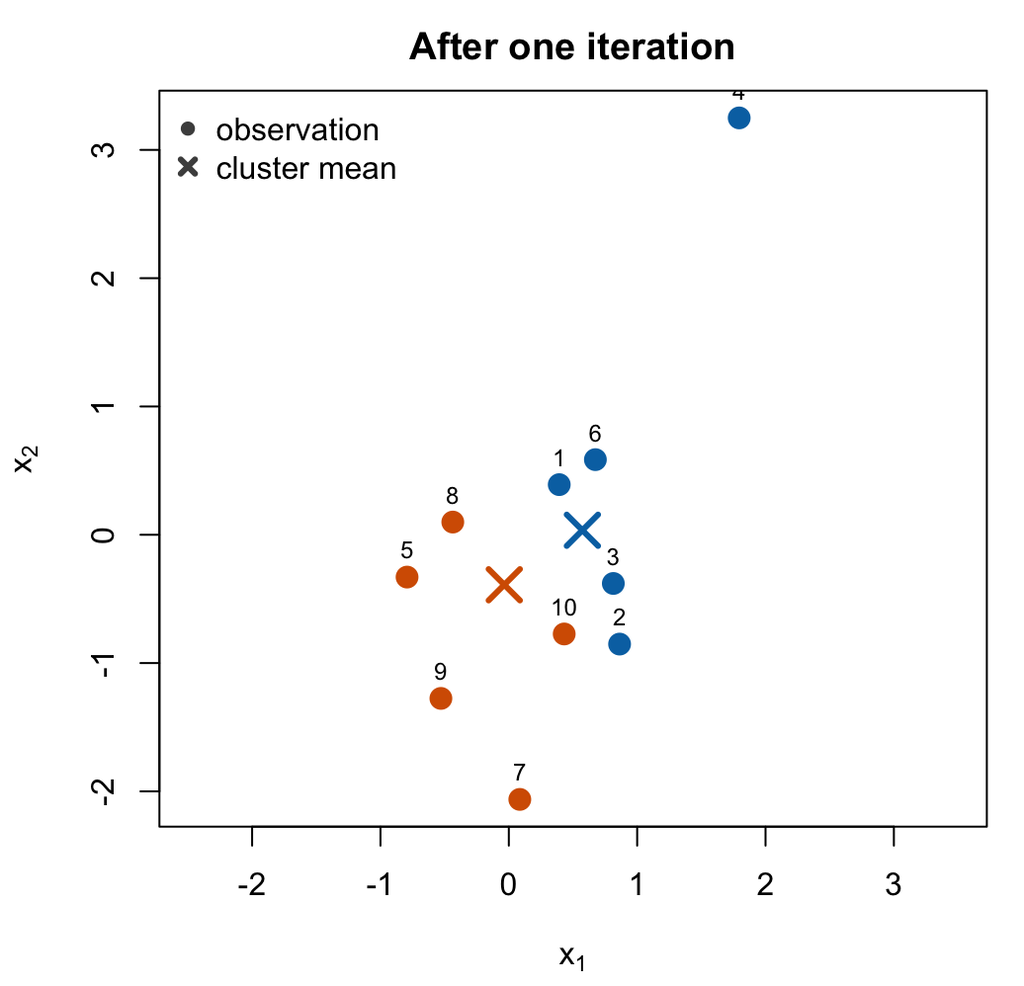

```r
ok <- c("#0072B2", "#D55E00")
par(mar = c(4.2, 4.2, 2.4, 1))
plot(X, col = ok[assign1], pch = 16, cex = 1.6, asp = 1,
     xlab = expression(x[1]), ylab = expression(x[2]),
     main = "After one iteration")
points(means1, col = ok, pch = 4, cex = 2.2, lwd = 3)
text(X, labels = 1:10, pos = 3, cex = 0.75)
legend("topleft", bty = "n", pch = c(16, 4), pt.lwd = c(1, 3), col = "grey30",
       legend = c("observation", "cluster mean"))
```

The two means after the first update are (0.573, 0.035) and (-0.035, -0.390). Reassigning to the nearest mean moves 3 of the 10 observations, so a single iteration has already undone much of the random start.

**(b) The full algorithm.**

```r
# Lloyd's algorithm. Works for any number of variables and any K.
my_kmeans <- function(X, K, init, max_iter = 100) {
  X <- as.matrix(X)
  a <- init
  M <- matrix(NA_real_, K, ncol(X))
  for (k in 1:K) if (sum(a == k) > 0) M[k, ] <- colMeans(X[a == k, , drop = FALSE])

  for (it in 1:max_iter) {
    # step 1: update means, keeping the previous mean for any cluster that is empty
    for (k in 1:K) if (sum(a == k) > 0) M[k, ] <- colMeans(X[a == k, , drop = FALSE])
    # step 2: assign each observation to the nearest mean
    d <- sapply(1:K, function(k) colSums((t(X) - M[k, ])^2))
    new <- max.col(-d, ties.method = "first")
    if (all(new == a)) { a <- new; break }
    a <- new
  }
  # recompute the means from the final assignments before returning
  for (k in 1:K) if (sum(a == k) > 0) M[k, ] <- colMeans(X[a == k, , drop = FALSE])

  list(assignment = a, means = M,
       wss = sum((X - M[a, , drop = FALSE])^2),
       iterations = it, converged = it < max_iter)
}
```

The within-cluster sum of squares is computed as $\sum_i\lVert x_i-m_{C(i)}\rVert^2$, which is the same quantity as the double sum in the question, written as one pass over the observations.

**(c) Two different random starts.**

```r
run1 <- my_kmeans(X, 2, assign0)

set.seed(7)
repeat {                                   # a different nonempty start
  assign0b <- sample(1:2, 10, replace = TRUE)
  if (all(table(factor(assign0b, levels = 1:2)) > 0) && any(assign0b != assign0)) break
}
run2 <- my_kmeans(X, 2, assign0b)

rbind(start_1 = assign0, final_1 = run1$assignment,
      start_2 = assign0b, final_2 = run2$assignment)
```

```
        [,1] [,2] [,3] [,4] [,5] [,6] [,7] [,8] [,9] [,10]
start_1    2    1    1    1    1    1    1    2    2     2
final_1    1    2    2    1    2    1    2    2    2     2
start_2    2    1    1    2    1    2    1    2    2     2
final_2    2    1    1    2    1    2    1    1    1     1
```

```r
round(run1$means, 4); round(run2$means, 4)
```

```
       [,1]    [,2]
[1,] 0.9540  1.4086
[2,] 0.0622 -0.7963
```

```
       [,1]    [,2]
[1,] 0.0622 -0.7963
[2,] 0.9540  1.4086
```

```r
c(wss_run1 = run1$wss, wss_run2 = run2$wss,
  iters_run1 = run1$iterations, iters_run2 = run2$iterations)
```

```
  wss_run1   wss_run2 iters_run1 iters_run2
  11.90389   11.90389    4.00000    3.00000
```

```r
same_grouping <- all(run1$assignment == run2$assignment) ||
                 all(run1$assignment == 3 - run2$assignment)
c(same_grouping_up_to_relabelling = same_grouping)
```

```
same_grouping_up_to_relabelling
                           TRUE
```

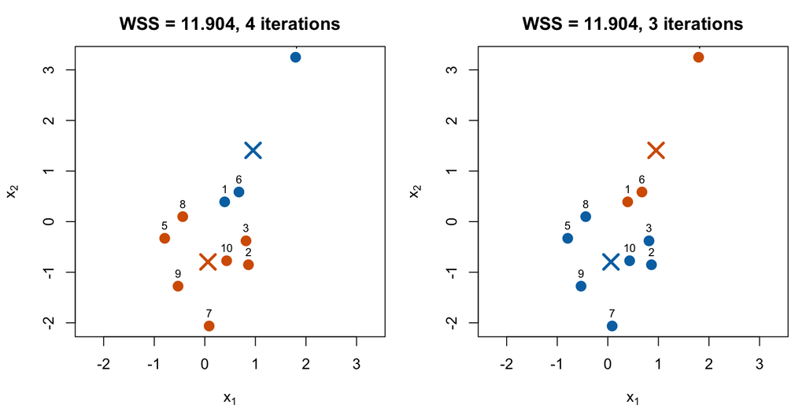

```r
par(mfrow = c(1, 2), mar = c(4.2, 4.2, 2.6, 1))
for (r in list(run1, run2)) {
  plot(X, col = ok[r$assignment], pch = 16, cex = 1.6, asp = 1,
       xlab = expression(x[1]), ylab = expression(x[2]),
       main = sprintf("WSS = %.3f, %d iterations", r$wss, r$iterations))
  points(r$means, col = ok, pch = 4, cex = 2.2, lwd = 3)
  text(X, labels = 1:10, pos = 3, cex = 0.75)
}
```

**The two runs agree.** They reach the same grouping up to relabelling, the same means, and the same within-cluster sum of squares, 11.9039, from different starts and in a different number of iterations (4 and 3).

That agreement is reassuring but not proof of optimality, and here it is actively misleading. With only 10 observations and $K=2$ I can enumerate every possible split and find the true minimum:

```r
best_wss <- Inf; best_lab <- NULL
for (m in 1:(2^10 - 2)) {                            # all 1022 nonempty 2-way splits
  lab <- 1 + as.integer(intToBits(m)[1:10])
  M <- t(sapply(1:2, function(k) colMeans(X[lab == k, , drop = FALSE])))
  w <- sum((X - M[lab, , drop = FALSE])^2)
  if (w < best_wss) { best_wss <- w; best_lab <- lab }
}
c(global_minimum = round(best_wss, 4), reached_by_both_runs = round(run1$wss, 4))
```

```
      global_minimum reached_by_both_runs
              8.6738              11.9039
```

```r
table(global_optimal_split = best_lab)
```

```
global_optimal_split
1 2
9 1
```

The global minimum is 8.6738, well below the 11.9039 both runs found. So both converged to the *same local optimum*, and it is not the best one. Scanning many starts shows how rare the global solution is:

```r
set.seed(99)
wss_many <- replicate(500, {
  repeat { s <- sample(1:2, 10, replace = TRUE)
           if (all(table(factor(s, levels = 1:2)) > 0)) break }
  my_kmeans(X, 2, s)$wss
})
table(round(wss_many, 4))
```

```
 8.6738 11.9039  17.137
      9     490       1
```

```r
c(share_reaching_global = mean(abs(wss_many - best_wss) < 1e-8))
```

```
share_reaching_global
                0.018
```

**Explanation.** Lloyd’s algorithm is a descent method: each step either lowers the objective or leaves it unchanged, so it must stop, but it can only stop at a partition that is stable under reassignment — a local optimum. Which one it reaches is determined entirely by the starting assignment, since every later step is deterministic.

Across 500 random starts there are only 3 distinct outcomes, and the basin leading to 11.904 attracts 98.0% of them, while the global optimum is found only 1.8% of the time. That is why two runs agreeing says little: they most likely fell into the same large basin. The global solution here splits off a single extreme observation, which gives that cluster zero within-cluster spread — a reminder that minimizing WSS rewards isolating outliers, and that the objective alone does not say which grouping is scientifically useful.

The practical lesson is the standard one: run K-means from many random starts and keep the lowest WSS. Two starts are not enough, and here even 500 find the optimum fewer than one time in fifty.

## Question 2: Image color compression

Pick your favorite color image and use your K-means function from Question 1 to cluster its pixels. For computational efficiency, resize the image to no more than $200\times200$ pixels and use its three RGB color channels.

1. Plot the original image and report its dimensions. Transform it into a data matrix with one observation per pixel and three variables: red, green, and blue. Report the dimensions of this matrix.
2. For $K=2,3,5,10$, apply your function to the pixel data. Report the cluster means and within-cluster sum of squares for each $K$. Reconstruct and plot each compressed image by replacing every pixel with its assigned cluster mean. Use the same RGB scale for all fits.
3. Which value of $K$ would you choose for this image? Briefly justify your choice using the reconstructed images and the within-cluster sums of squares.

### Answer

I use a photograph of my own, a photo-mosaic street scene. The original is 6368 × 8512 pixels, far too large to cluster directly, so it was resized once to fit inside 200 × 200 with the aspect ratio preserved. R has no JPEG decoder installed here, so the resize and RGB export were done once with Python, and everything after that — the clustering, the reconstruction, the plots — is the `my_kmeans` function from Question 1.

```python
# run once to produce data/mosaic-200.csv and data/mosaic-200-dim.txt
from PIL import Image
import numpy as np
im = Image.open("mosaic-hd.jpg").convert("RGB")   # 6368 x 8512
im.thumbnail((200, 200), Image.LANCZOS)           # both dimensions <= 200
a = np.asarray(im, dtype=np.float64) / 255.0      # scale RGB to [0, 1]
np.savetxt("data/mosaic-200.csv", a.reshape(-1, 3), delimiter=",",
           header="r,g,b", comments="", fmt="%.6f")
```

**(a) The image and its data matrix.**

```r
pixels <- as.matrix(read.csv("data/mosaic-200.csv"))   # one row per pixel: r, g, b in [0,1]
dims   <- scan("data/mosaic-200-dim.txt", quiet = TRUE)
H <- dims[1]; W <- dims[2]
c(image_height = H, image_width = W, original_height = 8512, original_width = 6368)
```

```
   image_height     image_width original_height  original_width
            200             150            8512            6368
```

```r
dim(pixels)
```

```
[1] 30000     3
```

```r
c(n_pixels = H * W, equals_rows = H * W == nrow(pixels))
```

```
   n_pixels equals_rows
      30000           1
```

```r
summary(pixels)
```

```
       r                g                b
 Min.   :0.1608   Min.   :0.1451   Min.   :0.1216
 1st Qu.:0.2902   1st Qu.:0.2980   1st Qu.:0.2667
 Median :0.5216   Median :0.4784   Median :0.4392
 Mean   :0.4791   Mean   :0.4578   Mean   :0.4372
 3rd Qu.:0.6471   3rd Qu.:0.6157   3rd Qu.:0.6039
 Max.   :0.7490   Max.   :0.7529   Max.   :0.8039
```

```r
# rebuild an H x W x 3 array from a matrix of pixel rows (row-major order)
to_image <- function(M) {
  A <- array(0, c(H, W, 3))
  for (j in 1:3) A[, , j] <- matrix(M[, j], H, W, byrow = TRUE)
  A
}
show_image <- function(A, main = "") {
  par(mar = c(0, 0, if (nzchar(main)) 1.6 else 0, 0))
  plot.new(); plot.window(c(0, W), c(0, H), asp = 1)
  rasterImage(as.raster(A), 0, 0, W, H)
  if (nzchar(main)) title(main, cex.main = 0.95)
}
```

[figure not shown]

```r
show_image(to_image(pixels), "Original, 150 x 200")
```

The resized image is 200 × 150 pixels. Flattening it gives a data matrix of **30000 × 3**: one observation per pixel, three variables holding its red, green, and blue intensity on a common [0, 1] scale. Note that the spatial arrangement is discarded — clustering sees an unordered cloud of 30,000 points in RGB space, and the image structure reappears only when each pixel is put back in its original position.

**(b) Clustering at K = 2, 3, 5, 10.**

```r
set.seed(43211)
Ks <- c(2, 3, 5, 10)
fits <- lapply(Ks, function(K) {
  repeat {
    init <- sample(1:K, nrow(pixels), replace = TRUE)
    if (all(table(factor(init, levels = 1:K)) > 0)) break
  }
  my_kmeans(pixels, K, init, max_iter = 300)
})
names(fits) <- paste0("K=", Ks)

summary_tab <- data.frame(
  K = Ks,
  WSS = sapply(fits, function(r) r$wss),
  iterations = sapply(fits, function(r) r$iterations),
  converged = sapply(fits, function(r) r$converged),
  smallest_cluster = sapply(fits, function(r) min(table(r$assignment))))
knitr::kable(summary_tab, digits = 2, row.names = FALSE,
             caption = "Within-cluster sum of squares by number of colors.")
```

Within-cluster sum of squares by number of colors.

| K | WSS | iterations | converged | smallest_cluster |
| --- | --- | --- | --- | --- |
| 2 | 664.87 | 9 | TRUE | 12968 |
| 3 | 335.82 | 15 | TRUE | 8699 |
| 5 | 198.48 | 50 | TRUE | 4089 |
| 10 | 91.51 | 66 | TRUE | 501 |

```r
for (i in seq_along(fits)) {
  M <- fits[[i]]$means
  colnames(M) <- c("red", "green", "blue")
  rownames(M) <- paste0("cluster", 1:nrow(M))
  cat("\nK =", Ks[i], " cluster means (RGB in [0,1]), with pixel counts:\n")
  print(round(cbind(M, n = as.vector(table(fits[[i]]$assignment))), 4))
}
```

```
K = 2  cluster means (RGB in [0,1]), with pixel counts:
            red  green   blue     n
cluster1 0.6134 0.5890 0.5633 17032
cluster2 0.3028 0.2854 0.2715 12968

K = 3  cluster means (RGB in [0,1]), with pixel counts:
            red  green   blue     n
cluster1 0.5100 0.4588 0.4189  8699
cluster2 0.2652 0.2547 0.2422 10043
cluster3 0.6461 0.6381 0.6252 11258

K = 5  cluster means (RGB in [0,1]), with pixel counts:
            red  green   blue    n
cluster1 0.4664 0.4377 0.4253 4089
cluster2 0.6565 0.6537 0.6445 9128
cluster3 0.3566 0.3312 0.3165 4150
cluster4 0.2345 0.2265 0.2133 6989
cluster5 0.5947 0.5349 0.4763 5644

K = 10  cluster means (RGB in [0,1]), with pixel counts:
             red  green   blue    n
cluster1  0.4740 0.3519 0.2828 1372
cluster2  0.6264 0.4873 0.3505 1804
cluster3  0.6292 0.6060 0.5869 3800
cluster4  0.3937 0.3889 0.3823 1766
cluster5  0.2317 0.2228 0.2093 6510
cluster6  0.4873 0.4647 0.4481 2293
cluster7  0.6705 0.6737 0.6647 6193
cluster8  0.5702 0.5403 0.5146 2987
cluster9  0.3059 0.3080 0.3079 2774
cluster10 0.3556 0.4500 0.5817  501
```

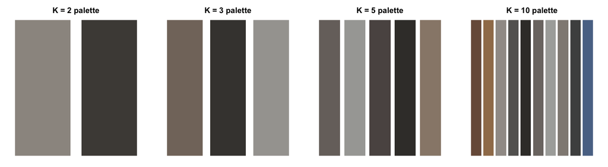

```r
par(mfrow = c(1, 4), mar = c(1, 1, 2, 1))
for (i in seq_along(fits)) {
  M <- fits[[i]]$means
  barplot(rep(1, nrow(M)), col = rgb(M[, 1], M[, 2], M[, 3]), border = NA,
          axes = FALSE, main = paste0("K = ", Ks[i], " palette"), cex.main = 0.95)
}
```

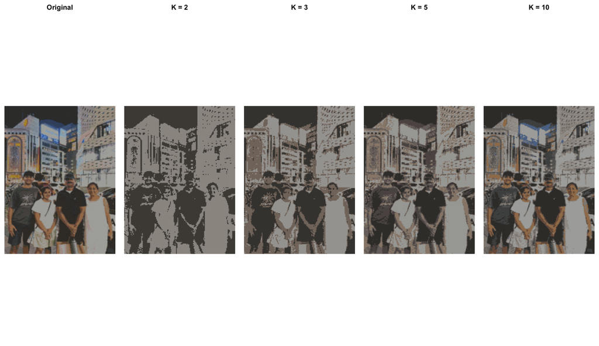

```r
par(mfrow = c(1, 5))
show_image(to_image(pixels), "Original")
for (i in seq_along(fits)) {
  recon <- fits[[i]]$means[fits[[i]]$assignment, , drop = FALSE]   # pixel -> its cluster mean
  show_image(to_image(recon), sprintf("K = %d", Ks[i]))
}
```

All four fits use the same [0, 1] RGB scale, so the palettes and reconstructions are directly comparable.

**(c) Which K I would choose.**

```r
wss <- sapply(fits, function(r) r$wss)
drop_per_K <- c(NA, -diff(wss) / diff(Ks))      # WSS removed per extra cluster
knitr::kable(data.frame(K = Ks, WSS = round(wss, 2),
                        pct_of_K2 = round(100 * wss / wss[1], 1),
                        wss_drop_per_added_cluster = round(drop_per_K, 2)),
             row.names = FALSE, caption = "Diminishing returns as K grows.")
```

Diminishing returns as K grows.

| K | WSS | pct_of_K2 | wss_drop_per_added_cluster |
| --- | --- | --- | --- |
| 2 | 664.87 | 100.0 | NA |
| 3 | 335.82 | 50.5 | 329.05 |
| 5 | 198.48 | 29.9 | 68.67 |
| 10 | 91.51 | 13.8 | 21.39 |

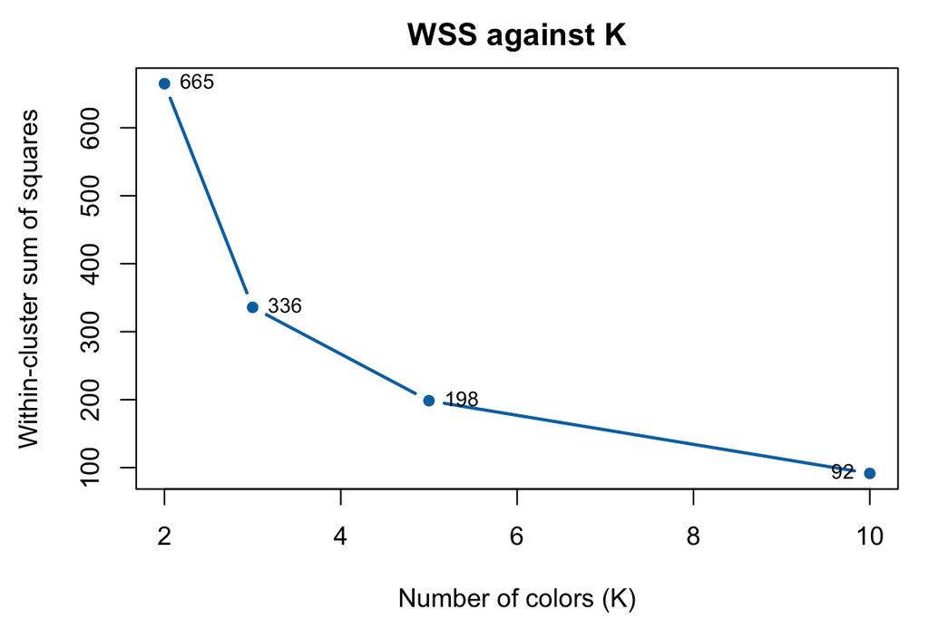

```r
par(mar = c(4.2, 4.4, 2.2, 1))
plot(Ks, wss, type = "b", pch = 16, lwd = 2, col = "#0072B2",
     xlab = "Number of colors (K)", ylab = "Within-cluster sum of squares",
     main = "WSS against K")
text(Ks, wss, labels = round(wss), pos = c(4, 4, 4, 2), cex = 0.8)
```

**I would choose K = 5.**

The within-cluster sum of squares falls steeply at first and then flattens: 665 at $K=2$, 336 at $K=3$, 198 at $K=5$, 92 at $K=10$. Each extra cluster between $K=2$ and $K=3$ removes about 329 units; between $K=5$ and $K=10$ it removes only about 21, roughly 15 times less. The curve has no sharp elbow — it never does for photographs, whose colors form a continuum rather than distinct groups — but the return per added color has clearly collapsed by $K=5$.

The images settle the choice, and they matter more than the number. At $K=2$ the picture is reduced to a light and a dark tone: the people are silhouettes and the buildings are a flat wash. At $K=3$ a mid-tone appears and the scene becomes legible as a street, but faces and skin are still a single block. At $K=5$ the reconstruction keeps the warm skin tones separate from the grey concrete and the dark clothing, and the image reads correctly at a glance. Going to $K=10$ adds visible gradation in the sky and the building facades and is the closest to the original, but the gain over $K=5$ is a refinement rather than a change in what the image shows.

So $K=5$ is where the picture stops losing content; $K=10$ buys polish at twice the palette. For a compression task — the point of the exercise — $K=5$ stores 30000 cluster labels drawn from 5 values plus 5 RGB triples, against 30000 × 3 full-precision numbers in the original, and keeps the image recognisable. If the goal were faithful reproduction rather than compression, I would take $K=10$ or beyond.

One caveat carried over from Question 1: each K was fit from a single random start, so these are local optima. With 30,000 observations the basins are far better behaved than in the 10-point example, but a careful analysis would repeat each K from several starts and keep the lowest WSS.

## Question 3: Hierarchical clustering of cars

The file `data/mtcars.csv` contains 11 numerical variables for 32 cars, including fuel economy, horsepower, and weight. The `car` column gives the model names; use it to label observations, not as a clustering variable. You may use existing hierarchical clustering functions for this question.

1. Standardize each numerical variable to have mean 0 and standard deviation 1. Using Euclidean distance, perform hierarchical clustering with single, complete, and average linkage. Plot the three dendrograms with the car names and compare the results.
2. Choose one linkage method and a number of clusters that you consider reasonable. Report the cluster memberships and a table of cluster means on the original variable scales. Describe the main characteristics of the groups and explain your choice using the dendrogram and table. Briefly explain why standardizing the variables matters for this analysis.

### Answer

**(a) Three linkages.**

```r
cars <- read.csv("data/mtcars.csv")
rownames(cars) <- cars$car
V <- cars[, setdiff(names(cars), "car")]          # car names label rows, never cluster
c(n_cars = nrow(V), n_variables = ncol(V))
```

```
     n_cars n_variables
         32          11
```

```r
names(V)
```

```
 [1] "mpg"  "cyl"  "disp" "hp"   "drat" "wt"   "qsec" "vs"   "am"   "gear"
[11] "carb"
```

```r
Z <- scale(V)                                     # mean 0, sd 1 per variable
round(colMeans(Z), 10)[1:4]; round(apply(Z, 2, sd), 10)[1:4]
```

```
 mpg  cyl disp   hp
   0    0    0    0
```

```
 mpg  cyl disp   hp
   1    1    1    1
```

```r
D <- dist(Z)                                      # Euclidean on standardized variables
```

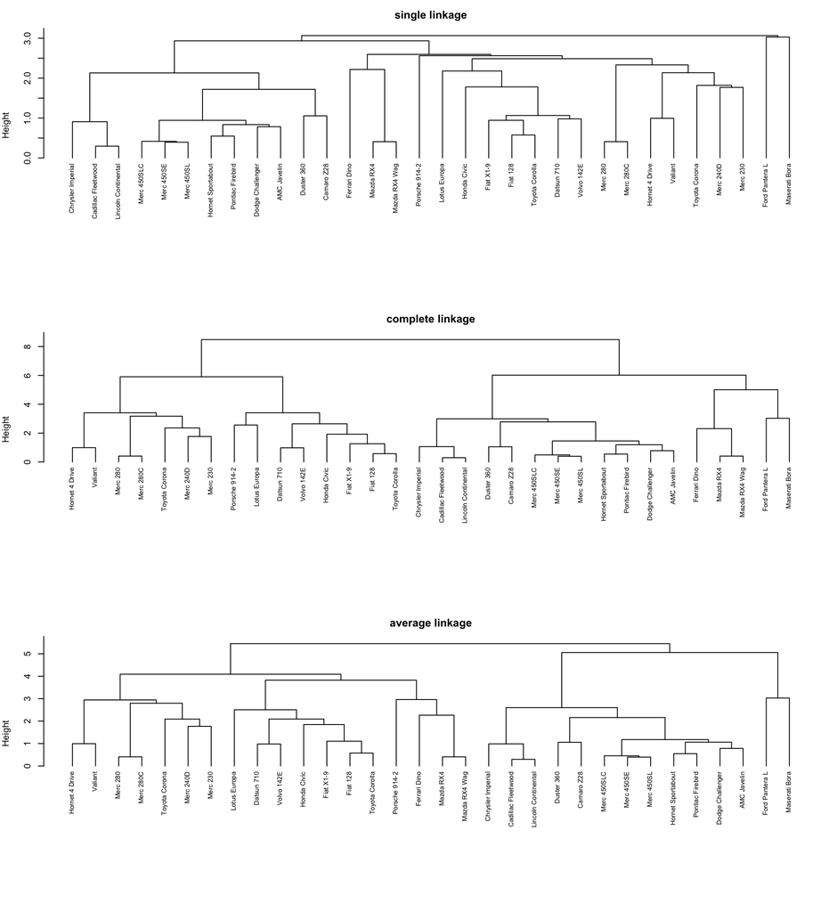

```r
par(mfrow = c(3, 1), mar = c(7.5, 4, 2.6, 1))
hc <- list()
for (m in c("single", "complete", "average")) {
  hc[[m]] <- hclust(D, method = m)
  plot(hc[[m]], main = paste(m, "linkage"), xlab = "", sub = "", cex = 0.72, hang = -1)
}
```

```r
comp <- t(sapply(names(hc), function(m)
  c(max_height = max(hc[[m]]$height),
    sizes_k3 = paste(sort(table(cutree(hc[[m]], 3)), decreasing = TRUE), collapse = "/"),
    sizes_k4 = paste(sort(table(cutree(hc[[m]], 4)), decreasing = TRUE), collapse = "/"))))
knitr::kable(comp, caption = "Cluster sizes produced by each linkage.")
```

Cluster sizes produced by each linkage.

|  | max_height | sizes_k3 | sizes_k4 |
| --- | --- | --- | --- |
| single | 3.06484087294866 | 30/1/1 | 18/12/1/1 |
| complete | 8.48016706493588 | 15/12/5 | 12/8/7/5 |
| average | 5.45468145471802 | 18/12/2 | 12/11/7/2 |

The three dendrograms differ sharply, and in the way the textbook predicts.

**Complete linkage** merges on the *farthest* pair, which penalises straggly groups and produces compact, balanced ones: 15/12/5 at $k=3$. Its merge heights also rise to 8.48, far above single linkage’s 3.06, giving clearly separated branches to cut.

**Average linkage** sits between the two, as expected, giving 18/12/2 — mostly balanced but still peeling off a small pair.

**(b) A chosen clustering.**

I use **complete linkage with $k=3$**, because its dendrogram is the only one of the three with three branches that are both well separated in height and non-trivial in size.

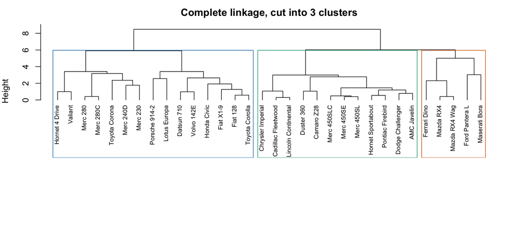

```r
k <- 3
clust <- cutree(hc$complete, k)
par(mar = c(7.5, 4, 2.4, 1))
plot(hc$complete, main = "Complete linkage, cut into 3 clusters",
     xlab = "", sub = "", cex = 0.72, hang = -1)
rect.hclust(hc$complete, k = k, border = c("#0072B2", "#009E73", "#D55E00"))
```

```r
for (i in 1:k) cat("\nCluster ", i, " (n = ", sum(clust == i), "): ",
                   paste(names(clust)[clust == i], collapse = ", "), "\n", sep = "")
```

```
Cluster 1 (n = 5): Mazda RX4, Mazda RX4 Wag, Ford Pantera L, Ferrari Dino, Maserati Bora

Cluster 2 (n = 15): Datsun 710, Hornet 4 Drive, Valiant, Merc 240D, Merc 230, Merc 280, Merc 280C, Fiat 128, Honda Civic, Toyota Corolla, Toyota Corona, Fiat X1-9, Porsche 914-2, Lotus Europa, Volvo 142E

Cluster 3 (n = 12): Hornet Sportabout, Duster 360, Merc 450SE, Merc 450SL, Merc 450SLC, Cadillac Fleetwood, Lincoln Continental, Chrysler Imperial, Dodge Challenger, AMC Javelin, Camaro Z28, Pontiac Firebird
```

```r
cluster_means <- aggregate(V, by = list(cluster = clust), FUN = mean)
cluster_means$n <- as.vector(table(clust))
knitr::kable(cluster_means[, c("cluster", "n", names(V))], digits = 2, row.names = FALSE,
             caption = "Cluster means on the original variable scales.")
```

Cluster means on the original variable scales.

| cluster | n | mpg | cyl | disp | hp | drat | wt | qsec | vs | am | gear | carb |
| --- | --- | --- | --- | --- | --- | --- | --- | --- | --- | --- | --- | --- |
| 1 | 5 | 18.50 | 6.80 | 223.40 | 198.80 | 3.84 | 3.00 | 15.62 | 0.00 | 1.00 | 4.60 | 5.20 |
| 2 | 15 | 24.65 | 4.53 | 131.65 | 91.33 | 3.90 | 2.58 | 19.16 | 0.93 | 0.53 | 3.93 | 1.80 |
| 3 | 12 | 15.05 | 8.00 | 357.62 | 194.17 | 3.12 | 4.10 | 17.14 | 0.00 | 0.00 | 3.00 | 3.08 |

**The three groups.**

*Cluster 1 (n = 5): sports cars.* Mazda RX4 and RX4 Wag, Ford Pantera L, Ferrari Dino, Maserati Bora. High power (mean hp 199) but light (wt 3.00), the quickest over a quarter mile (qsec 15.6, the lowest of the three), all manual (am = 1), with the most gears and carburettors. Mid-range fuel economy at 18.5 mpg — they are not efficient, they are fast and small.

*Cluster 2 (n = 15): economy cars.* Fiat 128, Honda Civic, Toyota Corolla, the small Mercedes, Lotus Europa and similar. Best economy by a wide margin (24.7 mpg), fewest cylinders (4.5), smallest displacement and lowest power (91 hp), lightest (2.58), and mostly straight engines (vs = 0.93).

*Cluster 3 (n = 12): large V8s.* Cadillac Fleetwood, Lincoln Continental, Chrysler Imperial, the big Mercedes, and the muscle cars. All eight cylinders (cyl = 8), largest displacement (358), heaviest (4.10), worst economy (15.1 mpg), all automatic with three gears.

The structure is essentially the familiar one: economy cars at one end, heavy V8s at the other, and a small high-performance group that is powerful like the V8s but light like the economy cars. That third group is what makes $k=3$ worth having over $k=2$ — cluster 1 and cluster 3 both have high horsepower and would be indistinguishable on power alone, but they separate cleanly on weight, transmission, and quarter-mile time.

**Why standardizing matters.**

```r
round(apply(V, 2, var), 2)
```

```
     mpg      cyl     disp       hp     drat       wt     qsec       vs
   36.32     3.19 15360.80  4700.87     0.29     0.96     3.19     0.25
      am     gear     carb
    0.25     0.54     2.61
```

```r
clust_unscaled <- cutree(hclust(dist(V), method = "complete"), 3)
c(sizes_unstandardized = paste(sort(table(clust_unscaled), decreasing = TRUE), collapse = "/"),
  agreement_with_standardized = round(mean(clust_unscaled == clust), 3))
```

```
       sizes_unstandardized agreement_with_standardized
                   "16/9/7"                     "0.375"
```

Euclidean distance adds squared differences across variables, so a variable contributes in proportion to its *units*, not its importance. On the raw scale `disp` has variance 15,361 and `hp` has 4,701, while `vs`, `am` and `drat` have variances below 1. Two cars 100 cubic inches apart in displacement are therefore treated as far more different than two cars that disagree on every binary and ratio variable combined. Unstandardized clustering is effectively clustering on displacement and horsepower alone, and the other nine variables are decoration.

The comparison above confirms it: clustering the raw data gives different group sizes and agrees with the standardized solution on only 38% of cars. Standardizing puts every variable on a common footing — one standard deviation of weight counts the same as one standard deviation of displacement — which is what lets the transmission and engine-shape variables influence the result at all.

The flip side is worth noting: standardizing is itself a choice, not a neutral act. It asserts that all eleven variables deserve equal weight, which inflates the influence of any variable that is mostly noise, and it treats the binary `vs` and `am` as though a standard deviation means the same thing for them as for a continuous measurement. A defensible alternative would weight variables by subject-matter importance, but equal weighting is the sensible default when there is no reason to prefer one over another.